# Medidas de tendencia central

[Marco Antonio Delgado Torres](https://marcodelgado1723.github.io/)

Estadística 2022-2, [Facultad de economía](http://www.economia.unam.mx/)

2/3/2022

### 1. ¿Qué son las medidas de tendencia central? 🤔

> “Son medidas estadísticas que se usan para describir como se puede resumir la localización de los datos. Ubican e identifican el punto alrededor del cual se centran los datos. Las medidas de tendencia central nos indican hacia donde se inclinan o se agrupan más los datos”

[UAEH (2020)](https://www.uaeh.edu.mx/division_academica/educacion-media/repositorio/2010/6-semestre/estadistica/medidas-tendencia-central.pdf)

Para este ejemplo, primero generaremos una serie de **100** números aleatorios entre **1** y **20** mediante la función `sample`. El argumento `TRUE` nos permitirá generar una muestra con remplazo:

```r
numeros <- sample(1:20, 100, TRUE)
numeros
```

```
##   [1] 10 13  3 10  3  9  5 17  6 19 13 13 18  9  6 11 18 19  3  3  3  6 20  9  9
##  [26]  3 12  3 15  5 16  9  5 18  9  8 15  9  6  9 12 16 15 17 15 20 10 10  4 18
##  [51] 19 12  3 11  6  8  8  5 18  2  3  2 13  6 16  6  3 18  5 19  2  6  3 18 12
##  [76] 11  8  5 15 12 18  4  8  5  5  3 13  4  6 17  6  6 12 19 15  1 15  8 18  2
```

### 2. Mediana 📍

> “La mediana es un conjunto es un valor que se encuentra a la mitad de los otros valores, es decir, que al ordenar los número de menor a mayor, éste se encuentra justamente en medio entre los que están por arriba.”

[QuestionPro (2022)](https://www.questionpro.com/blog/es/la-media-la-mediana-y-la-moda/)

Para obtener la **mediana**, podemos ordenar los `numeros` de menor a mayor, **el número que esté en medio de la muestra será la mediana**. Si utilizamos R, se puede hacer el cálculo de la **mediana** con la función `median`:

```r
mediana <- median(numeros)
mediana
```

```
## [1] 9
```

### 3. Media 🧮

> “Es el valor obtenido de la suma de todos los datos/valores dividida entre el numero de datos sumados. Es sacar o realizar el promedio de los datos”

[UAEH (2020)](https://www.uaeh.edu.mx/division_academica/educacion-media/repositorio/2010/6-semestre/estadistica/medidas-tendencia-central.pdf)

$$Media ={\frac {1}{n}}\sum _{i=1}^{n}a_{i}={\frac {a_{1}+a_{2}+\cdots +a_{n}}{n}}$$

Si usamos R, podemos obtener la media de una muestra si utlilizamos la función **mean**:

```r
media <- mean(numeros)
media
```

```
## [1] 9.94
```

### 4. Moda 📊

> “La moda es el valor que aparece más dentro de un conglomerado. En un grupo puede haber dos modas y se conoce como bimodal, y más de dos modas o multimodal cuando se repiten más de dos valores; se llama amodal cuando en un conglomerado no se repiten los valores.”

[QuestionPro (2022)](https://www.questionpro.com/blog/es/la-media-la-mediana-y-la-moda/)

Podemos saber cuál es la **frecuencia** (número de veces que aparece un elemento en una muestra) de cada número si dibujamos un **histograma** con la función `hist`, **aquel elemento con mayor frecuencia será la moda**:

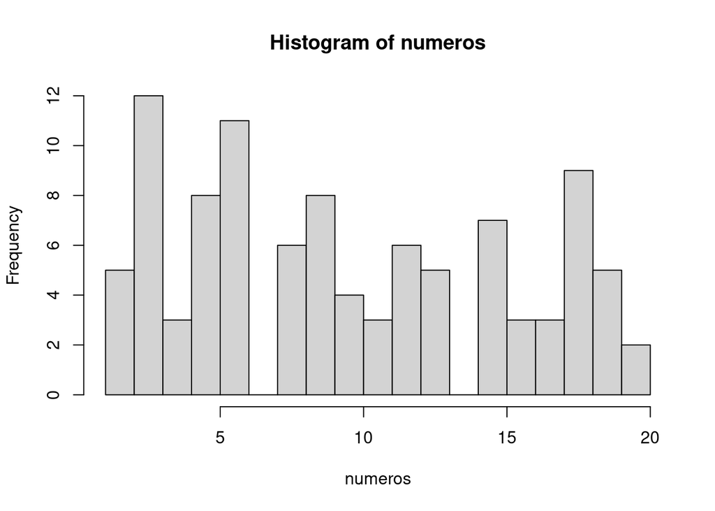

```r
# El argumento breaks nos permite dividir en histograma en las partes que queramos
hist(numeros, breaks = 20)
```

Para obtener un resultado con más precisión, podemos obtener la **moda** si generamos una **tabla de frecuencias** con la función `table` y la función `data.frame`, **aquel elemento con mayor frecuencia será la moda**:

```r
tabla.frecuencias <- data.frame(table(numeros))
tabla.frecuencias
```

```
##    numeros Freq
## 1        1    1
## 2        2    4
## 3        3   12
## 4        4    3
## 5        5    8
## 6        6   11
## 7        8    6
## 8        9    8
## 9       10    4
## 10      11    3
## 11      12    6
## 12      13    5
## 13      15    7
## 14      16    3
## 15      17    3
## 16      18    9
## 17      19    5
## 18      20    2
```

### 5. Ejercicio 👩‍💻👨‍💻✍

Aplica lo que aprendiste, obten la **mediana**, **media** y **moda** de la siguiente muestra de números:

```r
# Con la función seq, creamos una secuencia de 1 a 10 en intervalos de 0.1 en 0.1
secuencia <- seq(1, 10, 0.1)
muestra <- sample(secuencia, 100, TRUE)
muestra
```

```
##   [1] 8.7 2.2 7.2 7.0 3.1 2.0 5.0 8.7 8.8 6.9 5.8 6.0 3.5 2.4 4.6 8.0 9.7 1.8
##  [19] 2.6 3.8 5.0 7.5 2.5 1.2 3.2 3.1 7.5 5.4 4.6 6.8 8.5 6.7 4.1 4.4 9.2 8.5
##  [37] 9.4 9.1 3.9 4.3 5.5 4.2 6.3 8.0 8.4 3.4 6.6 7.0 3.1 3.2 6.0 5.6 8.4 3.2
##  [55] 8.6 7.6 2.7 1.4 6.3 8.0 9.6 3.3 9.5 4.2 8.5 8.3 9.3 7.2 6.2 3.2 2.2 9.6
##  [73] 8.9 6.8 3.6 1.8 9.6 9.2 8.9 1.3 9.0 8.2 8.1 3.0 1.1 2.3 6.6 4.4 2.6 1.4
##  [91] 1.6 4.8 5.5 6.2 1.2 4.6 6.5 4.8 5.3 2.3
```

##### Mediana

```r
# Aquí el cálculo de la mediana
mediana.muestra <- median(muestra)
mediana.muestra
```

```
## [1] 5.55
```

##### Media

```r
# Aquí el cálculo de la media
media.muestra <- mean(muestra)
media.muestra
```

```
## [1] 5.569
```

##### Moda

```r
# Aquí el cálculo de la moda
tabla.muestra <- data.frame(table(muestra))
tabla.muestra
```

```
##    muestra Freq
## 1      1.1    1
## 2      1.2    2
## 3      1.3    1
## 4      1.4    2
## 5      1.6    1
## 6      1.8    2
## 7        2    1
## 8      2.2    2
## 9      2.3    2
## 10     2.4    1
## 11     2.5    1
## 12     2.6    2
## 13     2.7    1
## 14       3    1
```

[output cut: 50 more lines]

💻[Código disponible en RStudio Cloud](https://rstudio.cloud/project/3671022)💻